# Project Python Foundations: FoodHub Data Analysis

By:Sushma Rao

# Start by importing the required libraries

```python
# import libraries for data manipulation
import numpy as np
import pandas as pd

# import libraries for data visualization
import matplotlib.pyplot as plt
import seaborn as sns
```

# Understanding the structure of the data

```python
# read the data
df = pd.read_csv('foodhub_order.csv')
# returns the first 5 rows
df.head()
```

|  | order_id | customer_id | restaurant_name | cuisine_type | cost_of_the_order | day_of_the_week | rating | food_preparation_time | delivery_time |
| --- | --- | --- | --- | --- | --- | --- | --- | --- | --- |
| 0 | 1477147 | 337525 | Hangawi | Korean | 30.75 | Weekend | Not given | 25 | 20 |
| 1 | 1477685 | 358141 | Blue Ribbon Sushi Izakaya | Japanese | 12.08 | Weekend | Not given | 25 | 23 |
| 2 | 1477070 | 66393 | Cafe Habana | Mexican | 12.23 | Weekday | 5 | 23 | 28 |
| 3 | 1477334 | 106968 | Blue Ribbon Fried Chicken | American | 29.20 | Weekend | 3 | 25 | 15 |
| 4 | 1478249 | 76942 | Dirty Bird to Go | American | 11.59 | Weekday | 4 | 25 | 24 |

Observations: The DataFrame has 9 columns as mentioned in the Data Dictionary. Data in each row corresponds to the order placed by a customer.

# Question 1: Write the code to check the shape of the dataset and write your observations based on that.

```python
df.shape
```

```
(1898, 9)
```

Observations: The DataFrame has 1898 rows and 9 columns.

# Question 2: Write the observations based on the below output from the info() method.

```python
# use info() to print a concise summary of the DataFrame
df.info()
```

```
<class 'pandas.core.frame.DataFrame'>
RangeIndex: 1898 entries, 0 to 1897
Data columns (total 9 columns):
 #   Column                 Non-Null Count  Dtype
---  ------                 --------------  -----
 0   order_id               1898 non-null   int64
 1   customer_id            1898 non-null   int64
 2   restaurant_name        1898 non-null   object
 3   cuisine_type           1898 non-null   object
 4   cost_of_the_order      1898 non-null   float64
 5   day_of_the_week        1898 non-null   object
 6   rating                 1898 non-null   object
 7   food_preparation_time  1898 non-null   int64
 8   delivery_time          1898 non-null   int64
dtypes: float64(1), int64(4), object(4)
memory usage: 133.6+ KB
```

obervations: 1. There are 4 categorical variables and the rest are numerical variables. 2.cost of the order is of the type float. 3.restaurant name,cuisine type,day of the week and rating are categorical variables. 4.order id,customer id,food preparation time and delivery time are of the type integer.

# Question 3: 'restaurant_name', 'cuisine_type', 'day_of_the_week' are object types. Write the code to convert the mentioned features to 'category' and write your observations on the same.

```python
df.restaurant_name = df.restaurant_name.astype('category')
df.cuisine_type = df.cuisine_type.astype('category')
df.day_of_the_week = df.day_of_the_week.astype('category')
df.info()
```

```
<class 'pandas.core.frame.DataFrame'>
RangeIndex: 1898 entries, 0 to 1897
Data columns (total 9 columns):
 #   Column                 Non-Null Count  Dtype
---  ------                 --------------  -----
 0   order_id               1898 non-null   int64
 1   customer_id            1898 non-null   int64
 2   restaurant_name        1898 non-null   category
 3   cuisine_type           1898 non-null   category
 4   cost_of_the_order      1898 non-null   float64
 5   day_of_the_week        1898 non-null   category
 6   rating                 1898 non-null   object
 7   food_preparation_time  1898 non-null   int64
 8   delivery_time          1898 non-null   int64
dtypes: category(3), float64(1), int64(4), object(1)
memory usage: 102.7+ KB
```

observations: 1. the data types of restaurant name,cuisine type,day of the week are converted to the type category.

# Question 4: Write the code to find the summary statistics and write your observations based on that.

```python
df.describe()
```

|  | order_id | customer_id | cost_of_the_order | food_preparation_time | delivery_time |
| --- | --- | --- | --- | --- | --- |
| count | 1.898000e+03 | 1898.000000 | 1898.000000 | 1898.000000 | 1898.000000 |
| mean | 1.477496e+06 | 171168.478398 | 16.498851 | 27.371970 | 24.161749 |
| std | 5.480497e+02 | 113698.139743 | 7.483812 | 4.632481 | 4.972637 |
| min | 1.476547e+06 | 1311.000000 | 4.470000 | 20.000000 | 15.000000 |
| 25% | 1.477021e+06 | 77787.750000 | 12.080000 | 23.000000 | 20.000000 |
| 50% | 1.477496e+06 | 128600.000000 | 14.140000 | 27.000000 | 25.000000 |
| 75% | 1.477970e+06 | 270525.000000 | 22.297500 | 31.000000 | 28.000000 |
| max | 1.478444e+06 | 405334.000000 | 35.410000 | 35.000000 | 33.000000 |

# Question 5: How many orders are not rated?

```python
a= df['rating'].value_counts()
a
```

```
Not given    736
5            588
4            386
3            188
Name: rating, dtype: int64
```

observation: 736 orders are not been rated.

# Exploratory Data Analysis (EDA)

# Question 6: Explore all the variables and provide observations on the distributions of all the relevant variables in the dataset.

```python
# function to plot a boxplot and a histogram along the same scale.


def histogram_boxplot(data, feature, figsize=(12, 7), kde=False, bins=None):
    """
    Boxplot and histogram combined

    data: dataframe
    feature: dataframe column
    figsize: size of figure (default (12,7))
    kde: whether to show the density curve (default False)
    bins: number of bins for histogram (default None)
    """
    f2, (ax_box2, ax_hist2) = plt.subplots(
        nrows=2,  # Number of rows of the subplot grid= 2
        sharex=True,  # x-axis will be shared among all subplots
        gridspec_kw={"height_ratios": (0.25, 0.75)},
        figsize=figsize
    )  # creating the 2 subplots
    sns.boxplot(
        data=data, x=feature, ax=ax_box2, showmeans=True, color="violet"
    )  # boxplot will be created and a star will indicate the mean value of the column
    sns.histplot(
        data=data, x=feature, kde=kde, ax=ax_hist2, bins=bins, palette="winter"
    ) if bins else sns.histplot(
        data=data, x=feature, kde=kde, ax=ax_hist2
    )  # For histogram
    ax_hist2.axvline(
        data[feature].mean(), color="green", linestyle="--"
    )  # Add mean to the histogram
    ax_hist2.axvline(
        data[feature].median(), color="black", linestyle="-"
    )  # Add median to the histogram
```

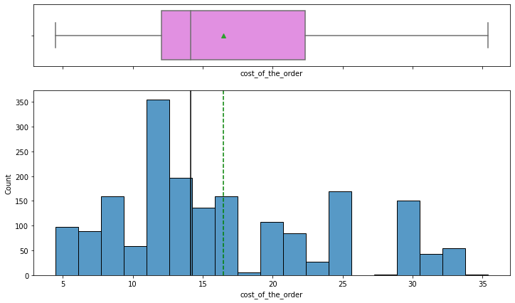

```python
histogram_boxplot(df,'cost_of_the_order')
```

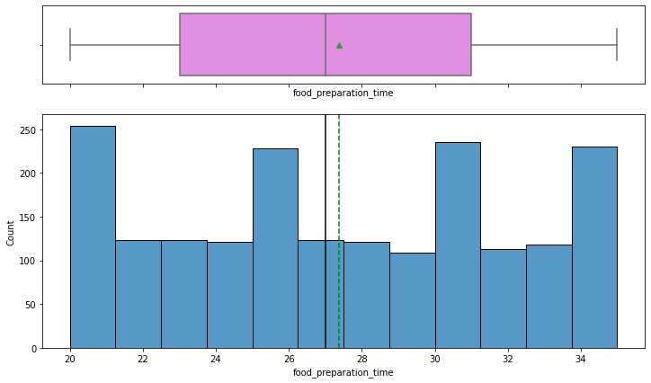

```python
histogram_boxplot(df,'food_preparation_time')
```

observations: 1.The mean and median are close to each other. 2.There are no outliers. 3.The time taken for food preparation does not show much variation, the distribution is uniform.

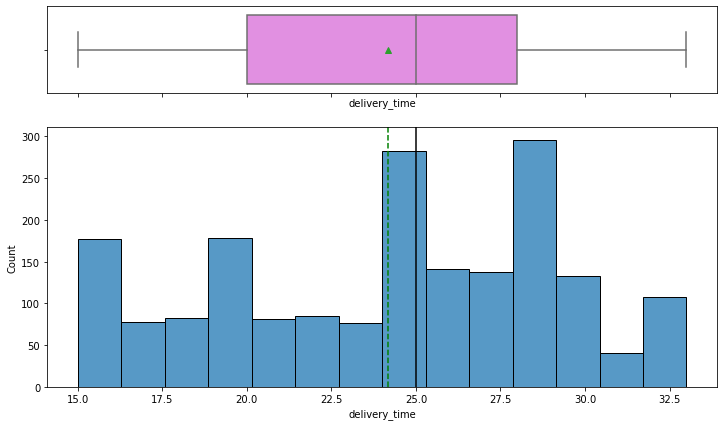

```python
histogram_boxplot(df,'delivery_time')
```

observations: 1.The mean is less than the median. 2.It doesn't show significantly any unusual delivery times, there are no outliers.

```
Weekend    0.711802
Weekday    0.288198
Name: day_of_the_week, dtype: float64
```

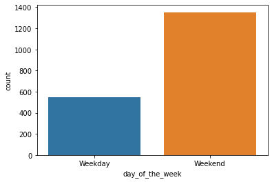

```python
sns.countplot(data= df,x="day_of_the_week")
df['day_of_the_week'].value_counts(normalize=True)
```

```python
df['day_of_the_week'].value_counts()
```

```
Weekend    1351
Weekday     547
Name: day_of_the_week, dtype: int64
```

observations: There are more weekends than weekdays ,which indicated that there are more number of orders on weekends compared to weekdays.

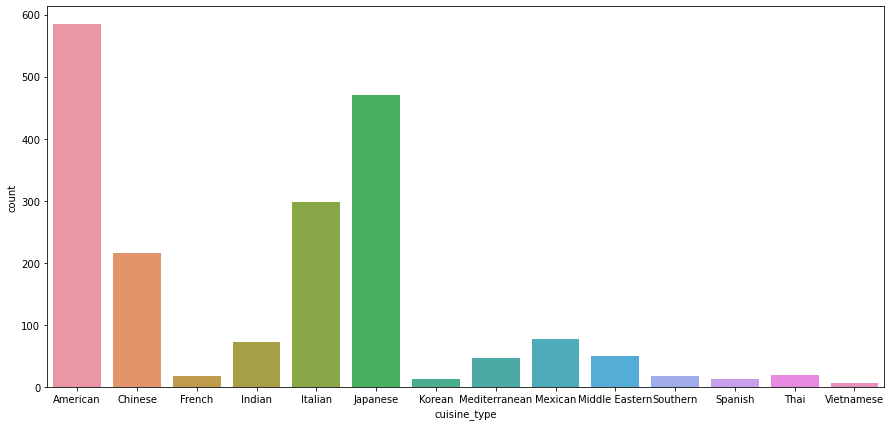

```python
plt.figure(figsize=(15,7))
sns.countplot(data= df,x="cuisine_type")
df['cuisine_type'].value_counts(normalize=True)
plt.show()
```

```python
df['cuisine_type'].value_counts()
```

```
American          584
Japanese          470
Italian           298
Chinese           215
Mexican            77
Indian             73
Middle Eastern     49
Mediterranean      46
Thai               19
French             18
Southern           17
Korean             13
Spanish            12
Vietnamese          7
Name: cuisine_type, dtype: int64
```

observations: 1.American cuisine is the most preferred cuisine followed by Japanese. 2.Vietnamese is the least preferred cuisine.

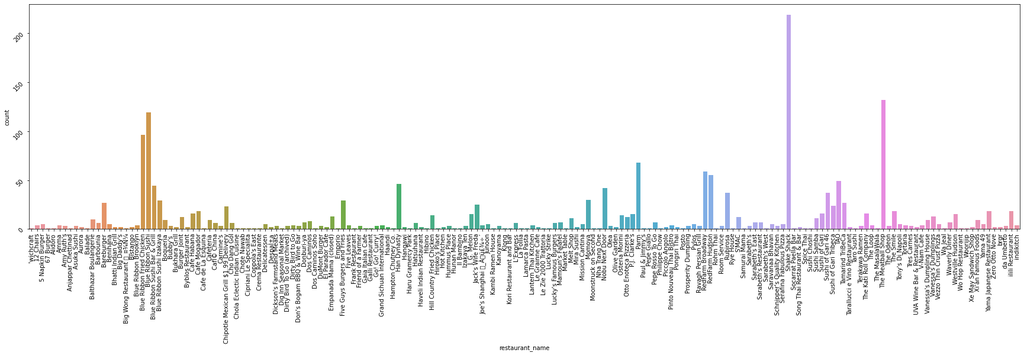

```python
plt.figure(figsize=(30,7))
sns.countplot(data= df,x="restaurant_name")
df['restaurant_name'].value_counts(normalize=True)
plt.xticks(rotation=90)
plt.yticks(rotation=45)# To rotate the x axis labls
plt.show()
```

```python
df['restaurant_name'].value_counts()
```

```
Shake Shack                  219
The Meatball Shop            132
Blue Ribbon Sushi            119
Blue Ribbon Fried Chicken     96
Parm                          68
                            ...
Klong                          1
Kambi Ramen House              1
Il Bambino                     1
Hunan Manor                    1
Lamarca Pasta                  1
Name: restaurant_name, Length: 178, dtype: int64
```

observations: 1. There are totally 178 different restaurants. 2. Shake Shack is the most preffered restaurant followed by The Meatball Shop and Blue Ribbon Sushi. 3. There are many Restaurants which have single orders.

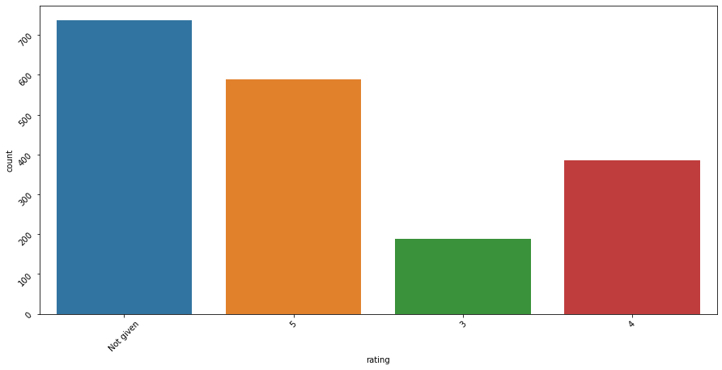

```python
plt.figure(figsize=(15,7))
sns.countplot(data= df,x="rating")
df['rating'].value_counts(normalize=True)
plt.xticks(rotation=45)
plt.yticks(rotation=45)# To rotate the x axis labls
plt.show()
```

observations: 1. Most of the orders are not been rated. 2. Among the rated orders , most of them have a 5 rating.

# Question 7: Write the code to find the top 5 restaurants that have received the highest number of orders.

```python
df1=df['restaurant_name'].value_counts().sort_values(ascending=False).reset_index()
df1.head()
```

|  | index | restaurant_name |
| --- | --- | --- |
| 0 | Shake Shack | 219 |
| 1 | The Meatball Shop | 132 |
| 2 | Blue Ribbon Sushi | 119 |
| 3 | Blue Ribbon Fried Chicken | 96 |
| 4 | Parm | 68 |

observations: The top 5 restaurants with the highest number of orders are Shake Shack, The Meatball Shop,Blue Ribbon Sushi, Blue Ribbon Fried Chiken and Parm.

# Question 8: Write the code to find the most popular cuisine on weekends.

```python
df_pre = df[df['day_of_the_week'] == 'Weekend']['cuisine_type']
df_pre
```

```
0         Korean
1       Japanese
3       American
6        Italian
11       Mexican
          ...
1891    American
1892     Chinese
1893     Mexican
1894    American
1897    Japanese
Name: cuisine_type, Length: 1351, dtype: category
Categories (14, object): ['American', 'Chinese', 'French', 'Indian', ..., 'Southern', 'Spanish', 'Thai', 'Vietnamese']
```

```python
df_pre.value_counts()
```

```
American          415
Japanese          335
Italian           207
Chinese           163
Mexican            53
Indian             49
Mediterranean      32
Middle Eastern     32
Thai               15
French             13
Korean             11
Southern           11
Spanish            11
Vietnamese          4
Name: cuisine_type, dtype: int64
```

observation: American cuisine is the most popular cuisine on weekends.

# Question 9: Write the code to find the number of total orders where the cost is above 20 dollars. What is the percentage of such orders in the dataset?

```python
df_20 = df[df['cost_of_the_order'] > 20.00]['order_id']
a=df_20.count()
a
```

```
555
```

```python
b=df['cost_of_the_order'].count()
b
```

```
1898
```

```python
per_order=(a/b)*100
per_order
```

```
29.24130663856691
```

observation: The precentage of orders where the cost is above 20 dollars is 29.24%.

# Question 10: Write the code to find the mean delivery time based on this dataset.

```python
df['delivery_time'].mean()
```

```
24.161749209694417
```

observation: The mean delivery time based on this data set is 24.16 min.

# Question 11: Suppose the company has decided to give a free coupon of 15 dollars to the customer who has spent the maximum amount on a single order. Write the code to find the ID of the customer along with the order details.

```python
df_max= df['cost_of_the_order'].max()
df_max
```

```
35.41
```

```python
cus_id = df[df['cost_of_the_order'] == 35.41]
cus_id
```

|  | order_id | customer_id | restaurant_name | cuisine_type | cost_of_the_order | day_of_the_week | rating | food_preparation_time | delivery_time |
| --- | --- | --- | --- | --- | --- | --- | --- | --- | --- |
| 573 | 1477814 | 62359 | Pylos | Mediterranean | 35.41 | Weekday | 4 | 21 | 29 |